# MIS/ECB/FTN Ordination Plotting

#Install packages and set up environment

```
## [1] "/Users/callahanmcgovern/Desktop/Research/LHM/metabarcoding.2/16s_analyses/by_site/ps_MIS_ECB_FTN"
```

# Motivation

Ordination plots are a great way to see any clustering or other patterns of microbiota (dis)similarity in (many) samples.

Ordinations like PCA or PCoA show the largest patterns of variation in your data, and constrained ordination techniques like RDA or CCA can show you microbial variation that could be explained by other variables in your sample_data (but interpret constrained ordinations with care, and ideally test for the statistical significance of any hypothesised associations using a method like PERMANOVA

When creating an ordination plot, you first need to prepare the microbiota variables.Decide at which taxonomic rank to aggregate your data, e.g. “Genus”. Consider transforming the microbial counts, e.g. using the “clr” (centred log ratio) transformation, which is often recommended for compositional data (like sequencing data)

Some methods, such as PCoA, require a matrix of pairwise distances between samples, which you can easily calculate with dist_calc(). Normally you should NOT transform your data when using a distance-based method, but it is useful to record an “identity” transformation anyway, to make it clear you have not transformed your data.

# PCA - Principal Components Analysis

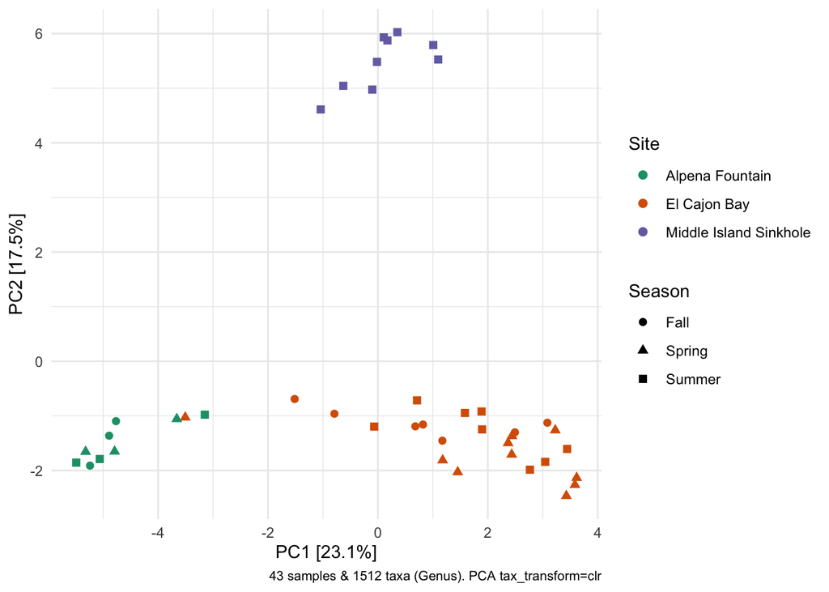

```r
pca <- ps_MIS_ECB_FTN %>%
  tax_transform("clr", rank = "Genus") %>%
  # when no distance matrix or constraints are supplied, PCA is the default/auto ordination method
  ord_calc() %>%
  ord_plot(color = "Site", shape = "Season", size = 2) +
  scale_colour_brewer(palette = "Dark2")

pca
```

The relative length of each loading vector indicates its contribution to each PCA axis shown, and allows you to roughly estimate which samples will contain more of that taxon e.g. samples on the left of the plot below, will typically contain more Microcoleus than samples on the right, and this taxon contributes heavily to the PC1 axis.

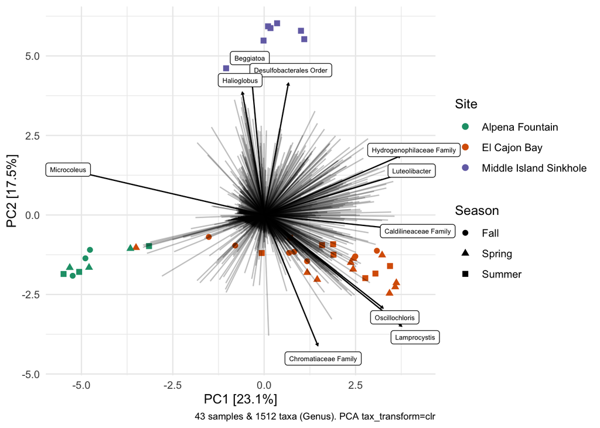

```r
pca_taxa <- ps_MIS_ECB_FTN %>%
  tax_transform("clr", rank = "Genus") %>%
  # when no distance matrix or constraints are supplied, PCA is the default/auto ordination method
  ord_calc(method = "PCA") %>%
  ord_plot(color = "Site", shape = "Season", plot_taxa = 1:10, size = 2) +
  scale_colour_brewer(palette = "Dark2")
print(pca_taxa)
```

# MDS with bray curtis distance instead. You cant plot taxa as vectors here though.

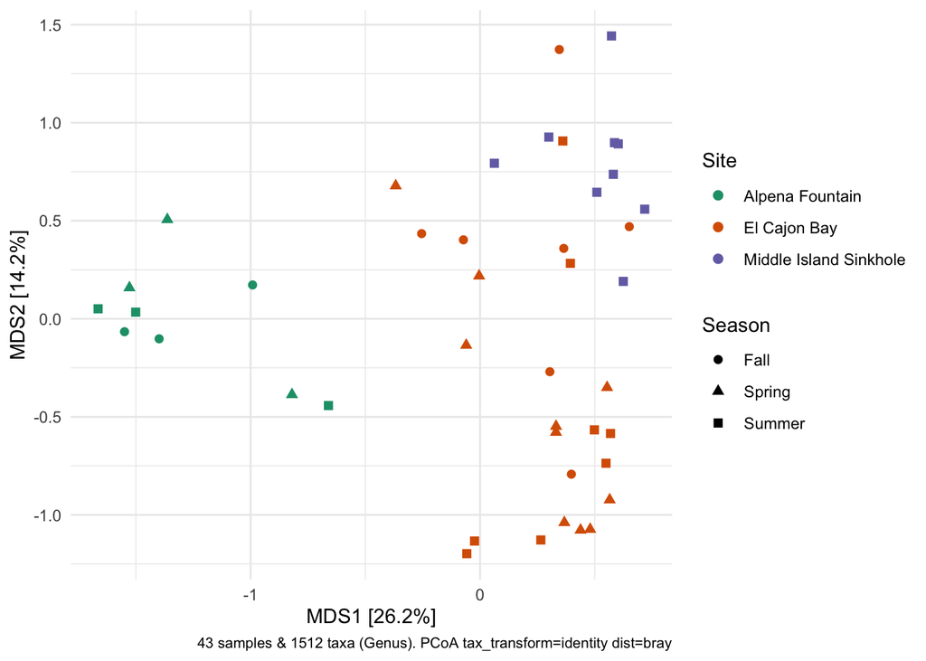

```r
MDS <- ps_MIS_ECB_FTN %>%
  tax_transform("identity", rank = "Genus") %>% # don't transform!
  dist_calc("bray") %>%
  ord_calc("PCoA") %>%
  ord_plot(color = "Site", shape = "Season", size = 2) +
  scale_colour_brewer(palette = "Dark2")
print(MDS)
```

## Further dimensions

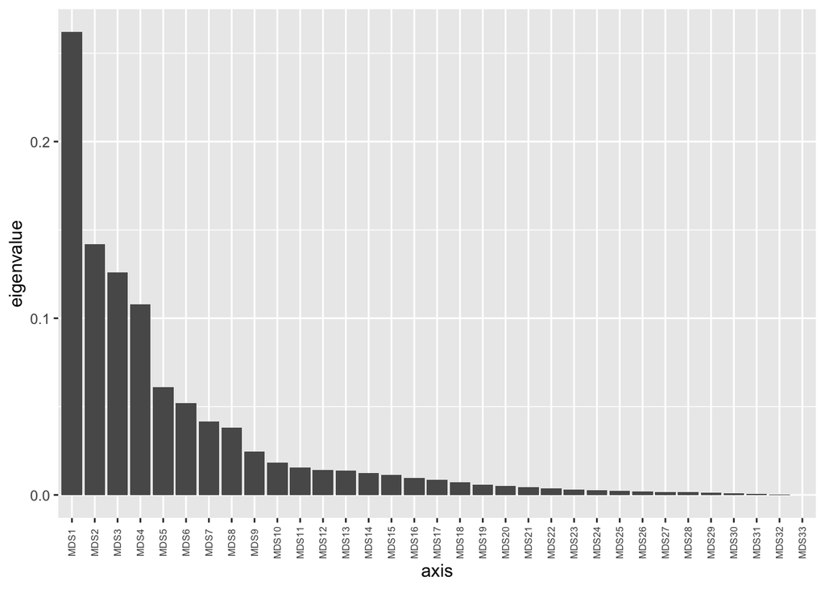

```r
dims <- ps_MIS_ECB_FTN %>%
  tax_transform("identity", rank = "Genus") %>% # don't transform!
  dist_calc("bray") %>%
  ord_calc("PCoA") %>%
  ord_get() %>%
  phyloseq::plot_scree() + theme(axis.text.x = element_text(size = 6))
print(dims)
```

Pick 2 axes to look at:

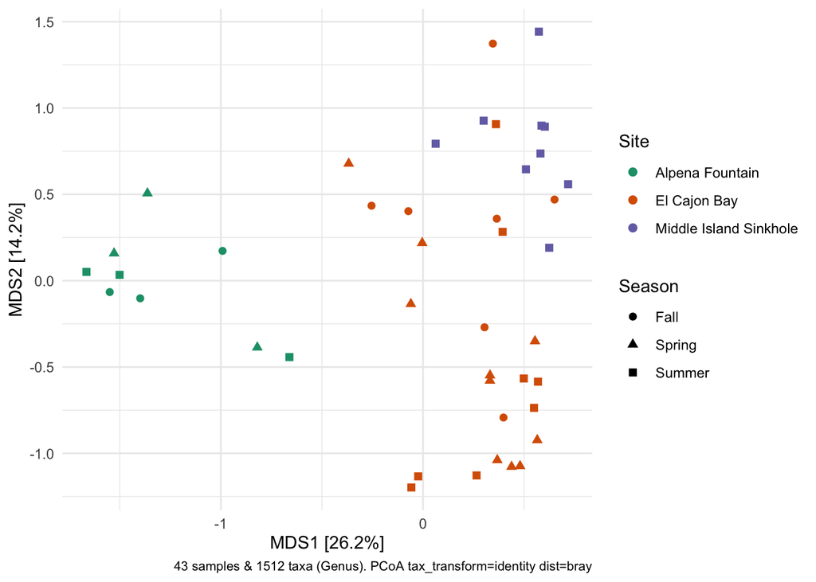

```r
dims2 <- ps_MIS_ECB_FTN %>%
  tax_transform("identity", rank = "Genus") %>% # don't transform!
  dist_calc("bray") %>%
  ord_calc("PCoA") %>%
  ord_plot(axes = c(1, 2), color = "Site", shape = "Season", size = 2) +
  scale_colour_brewer(palette = "Dark2")
print(dims2)
```

## Univariable distribution side panels

As the ordination figures are (pretty much) just standard ggplot objects, integration with other ggplot extensions like ggside is typically possible. Below are a couple of examples using the ggside package to add univariable distribution plots for each PC, split by the same groups as in the main plot.

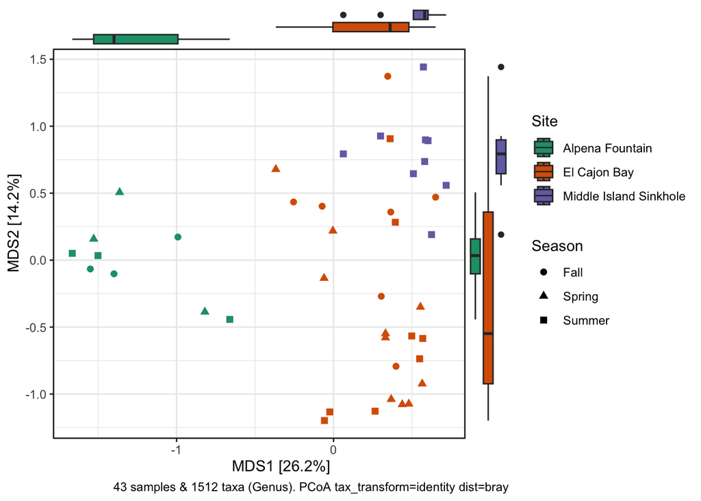

```r
#install.packages("ggside")
library(ggside)

side <- ps_MIS_ECB_FTN %>%
  tax_transform("identity", rank = "Genus") %>%
  dist_calc(dist = "bray") %>%
  ord_calc("PCoA") %>%
  ord_plot(color = "Site", shape = "Season", size = 2) +
  scale_colour_brewer(palette = "Dark2", aesthetics = c("fill", "colour")) +
  theme_bw() +
  ggside::geom_xsideboxplot(aes(fill = Site, y = Site), orientation = "y") +
  ggside::geom_ysideboxplot(aes(fill = Site, x = Site), orientation = "x") +
  ggside::scale_xsidey_discrete(labels = NULL) +
  ggside::scale_ysidex_discrete(labels = NULL) +
  ggside::theme_ggside_void()
print(side)
```

[figure not shown]

```r
side2 <- ps_MIS_ECB_FTN %>%
  tax_transform("identity", rank = "Genus") %>%
  dist_calc(dist = "bray") %>%
  ord_calc("PCoA") %>%
  ord_plot(color = "Site", shape = "Season", size = 2) +
  scale_colour_brewer(palette = "Dark2", aesthetics = c("fill", "colour"), name = "IBD") +
  theme_bw() +
  ggside::geom_xsidedensity(aes(fill = Site), alpha = 0.5, show.legend = FALSE) +
  ggside::geom_ysidedensity(aes(fill = Site), alpha = 0.5, show.legend = FALSE) +
  ggside::theme_ggside_void()
print(side2)
```